# ESM203 Assignment 3: Homework 3 Analysis

Sophia Leiker

11/10/2021

### Analysis

1. Set up a simple mass balance model of groundwater driven by inputs and outputs.

Recall that $\delta S = Inputs - Outputs$

values: 18.2 and 5.4

2. Specify the initial inputs and outputs for 2000. This requires determining the inputs and losses of groundwater in Figure 2.

Some Hints:

```r
out00 = 18.2
chng00 = -5.4
in00 =  chng00 + out00
in00
```

```
## [1] 12.8
```

3. Determine the conditions at the end of the simulation (2050). This requires determining the inputs and outputs of groundwater in Figure 4.

```r
out50 = 27
chng50 = -16.7
in50 = chng50 + out50
in50
```

```
## [1] 10.3
```

4. Fit a linear trend in the input and output terms between the year 2000 and 2050 in order to determine the transient changes in recharge and withdrawals over this 50-year period.

```r
# fit linear trend lines between the years 2000-2050
year <- c(2000, 2050)

# trend line for inputs
in_trend <- c(in00, in50)
in_lm <- lm(in_trend ~ year)
in_lm
```

```
##
## Call:
## lm(formula = in_trend ~ year)
##
## Coefficients:
## (Intercept)         year
##      112.80        -0.05
```

```r
# trend line for outputs
out_trend <- c(out00, out50)
out_lm <- lm(out_trend ~ year)
out_lm
```

```
##
## Call:
## lm(formula = out_trend ~ year)
##
## Coefficients:
## (Intercept)         year
##    -333.800        0.176
```

```r
# create a dataframe with all the years from 2000-2050
years <- seq(from=2000, to=2050, by=1)
massbal <- as.data.frame(years)

# use the equation from lm to fill in columns for ins and outs
massbal$ins = -0.05*massbal$years +  112.8
massbal$outs = 0.176*massbal$years - 333.8

head(massbal)
```

```
##   years   ins   outs
## 1  2000 12.80 18.200
## 2  2001 12.75 18.376
## 3  2002 12.70 18.552
## 4  2003 12.65 18.728
## 5  2004 12.60 18.904
## 6  2005 12.55 19.080
```

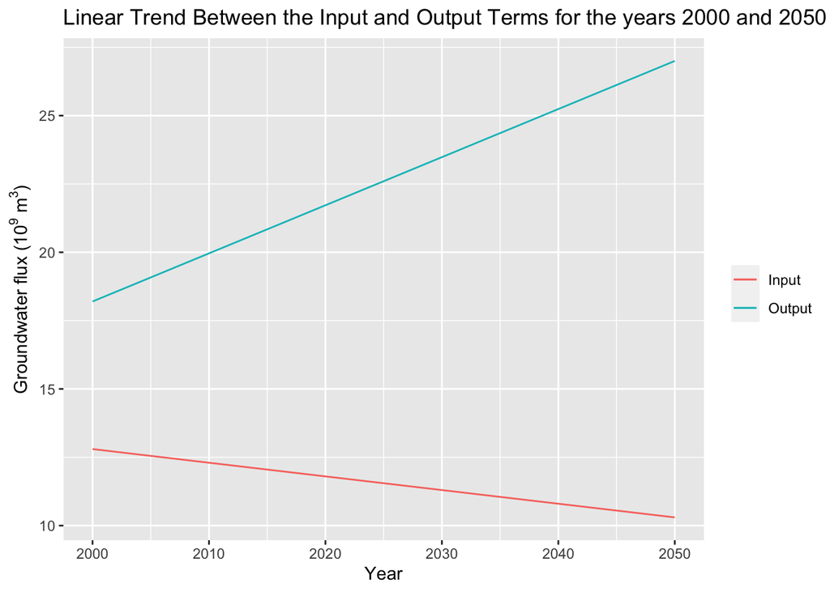

```r
# plot the ins and outs over the years - what will happen to storage based on these trends?
ggplot(massbal) +
  geom_line(aes(x=years, y=ins, col='Input')) +
  geom_line(aes(x=years, y=outs, col='Output')) +
  xlab("Year") +
  ylab(TeX("Groundwater flux ($10^9$ $m^3$)")) +
  theme(legend.title = element_blank()) +
  labs(title = "Linear Trend Between the Input and Output Terms for the years 2000 and 2050")
```

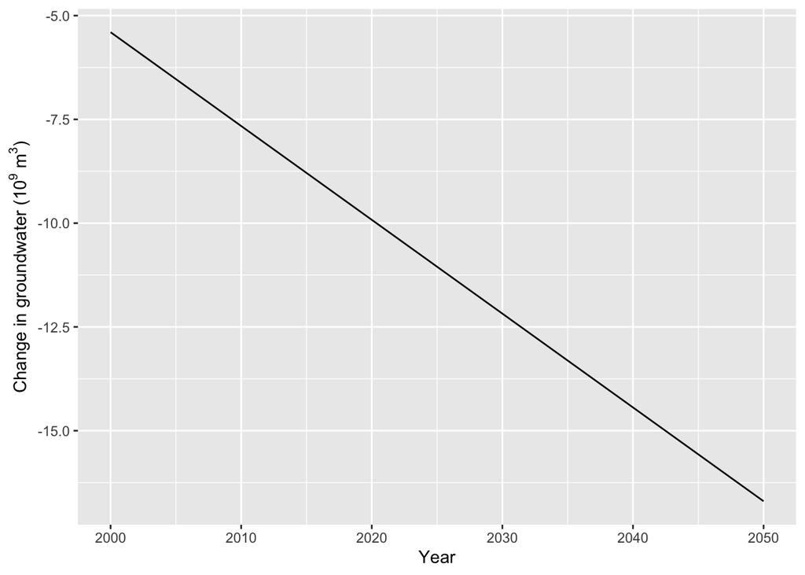

```r
# can do mass balance for each year to see the changes
massbal$chnge = massbal$ins - massbal$outs
ggplot(massbal) +
  geom_line(aes(x=years, y=chnge)) +
  xlab("Year") +
  ylab(TeX("Change in groundwater ($10^9$ $m^3$)"))
```

```r
# can also get the linear model of the change each year
lm(c(chng00, chng50) ~ year)
```

```
##
## Call:
## lm(formula = c(chng00, chng50) ~ year)
##
## Coefficients:
## (Intercept)         year
##     446.600       -0.226
```

```r
massbal$chnge_lm <- -0.2266*massbal$years + 446.6
```

5. Calculate the changes in groundwater resources from 2000-2050 for at least three scenarios based on varying initial conditions of groundwater availability: The expected amount of groundwater (from section 2, above) as well as for upper and lower estimates provided in section 2.
- From Curmi et al., Figure 7, you can assume that the expected value of groundwater resources in 2000 was *350x10^9 m3*. Let’s further assume that uncertainty regarding this value follows a normal distribution around that mean value, with a standard deviation of 115x109 m3.
- Based on a normal distribution with this mean and standard deviation, there is a 90% chance that the actual amount of groundwater in CA is somewhere between the approximate lower limit of *190x10^9 m3* and an approximate upper limit of *550x10^9 m3*.

```r
# all of the flows were also 10^9, so there is no need for unit conversions

# integrate over the water lost starting in 2000
water_lost <- function(year){
  int <- integrate(function(x){-0.226*x + 446.6}, lower = 2000, upper = year) #this function comes from the linear model of change over year
  return(int$value)
}
massbal$w_lost <- sapply(massbal$years, water_lost)

# create columns for the average, lower bounds, and upper bouds
massbal$gw_storage = massbal$w_lost + 350
massbal$gw_low = massbal$w_lost + 190
massbal$gw_upp = massbal$w_lost + 550

head(massbal)
```

```
##   years   ins   outs  chnge chnge_lm  w_lost gw_storage  gw_low  gw_upp
## 1  2000 12.80 18.200 -5.400  -6.6000   0.000    350.000 190.000 550.000
## 2  2001 12.75 18.376 -5.626  -6.8266  -5.513    344.487 184.487 544.487
## 3  2002 12.70 18.552 -5.852  -7.0532 -11.252    338.748 178.748 538.748
## 4  2003 12.65 18.728 -6.078  -7.2798 -17.217    332.783 172.783 532.783
## 5  2004 12.60 18.904 -6.304  -7.5064 -23.408    326.592 166.592 526.592
## 6  2005 12.55 19.080 -6.530  -7.7330 -29.825    320.175 160.175 520.175
```

### Create plots

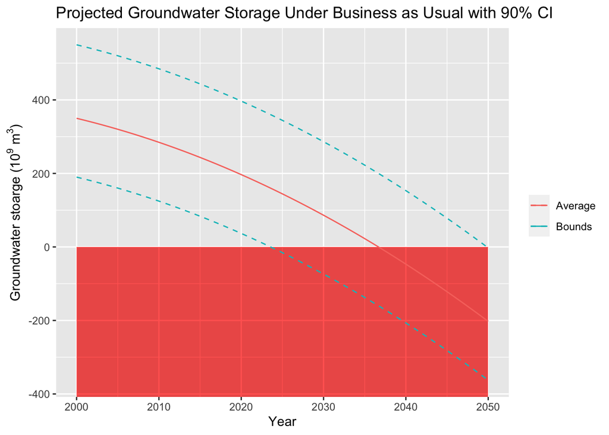

```r
# use ggplot here to create a beautiful plot to include

# example plot which we don't need to show - not the nicest
ggplot(massbal) +
  geom_rect(aes(ymin=-Inf, ymax=0, xmin=2000, xmax=2050), alpha = 0.02, fill='red') +
  geom_line(aes(x=years, y=gw_storage, col='Average')) +
  geom_line(aes(x=years, y=gw_low, col='Bounds'), linetype='dashed') +
  geom_line(aes(x=years, y=gw_upp, col='Bounds'), linetype='dashed') +
  xlab("Year") +
  ylab(TeX("Groundwater stoarge ($10^9$ $m^3$)")) +
  theme(legend.title = element_blank()) +
  ggtitle("Projected Groundwater Storage Under Business as Usual with 90% CI")
```

### All that is left is for the presentation!

Your findings should be presented in the form of a brief 1-2 page technical brief. This document should summarize your approach, present your analysis in 1 or 2 clear and compelling figures, and provide a set of key findings that could be incorporated into a broader policy-focused presentation to stakeholders. Any figures should contain information regarding uncertainty, and should be able to “stand alone” from the work based on only the title, labels, figure text, and a brief caption. Your brief should also highlight any key assumptions, data sources, and provide recommendations on next steps to improve or refine your assessment. Your brief should be written for a broad audience, but you should make sure to communicate in a scientific/ professional manner.